# 7.7 Coordinate descent

code

share

► [Chapter 7: Second order methods](https://jermwatt.github.io/mlrefined/index.html)  
7.7 Coordinate descent

More often than not we cannot solve for the individual weight update

\begin{equation} w_n^{k} = \underset{w_n}{\text{argmin}}\,\,\,g\left(w_1^{k},w_2^{k},w_3^{k},...,w_{n-1}^{k},w_{n\vphantom{+1}}^{\,},w_{n+1}^{k-1},...,w_N^{k-1}\right). \end{equation}

by solving the corresponding first order equation. Therefore we approximate the above by either applying gradient descent steps or Newton's method steps along each individual input weight.

Often in practice only a single gradient descent or Newton step is made in each direction - a rough approximation to the true minimum desired - but this is done for efficiency's sake. Our goal is not to minimize $g$ a in just a single variable but the entire set of weights, and thus in terms of computation applying more frequent updates to all weights as opposed to focusing on convergence in each individual input is often a more efficient choice practically speaking.

#### Example 1: Minimizing Least Squares

The Least Squares cost function for linear regression is a convex quadratic function (as we saw in Example 4 of our post on [linear regression](https://jermwatt.github.io/mlrefined/blog_posts/Linear_Supervised_Learning/Part_1_Linear_regression.html)), thus we can directly apply our coordinate descent code for minimizing a quadratic function to solve the linear regression problem by simply translating the Least Squares cost into the standard quadratic form. Given the form of the matrix $\mathbf{C}$ in this instance this approach is limited to use when the dimension of the input $N$ is less than around ten thousand, at which point the matrix cannot be stored or computed with effectively. Otherwise it is better to apply coordinate descent algorithm directly to the explicit form of the Least Squares cost function so we avoid dealing with such large matrices, which we do below. While expressed in different more cost-saving terms, these updates will of course take on the same numerical values as those of the quadratic form.

For a dataset of $P$ points $\left(\mathbf{x}_{1},y_{1}\right),\,\left(\mathbf{x}_{2},y_{2}\right),\,...,\,\left(\mathbf{x}_{P},y_{P}\right)$ we re-annotate using the compact notation

\begin{equation} \mathbf{w} \longleftarrow \left[\begin{array}{c} w_{0}\\ \mathbf{w} \end{array}\right] \,\,\,\,\text{and}\,\,\,\,\, \mathbf{x}_{p}\longleftarrow\left[\begin{array}{c} 1\\ \mathbf{x}_{p}. \end{array}\right] \end{equation}

and write our Least Squares cost function as

\begin{equation} \,g\left(\mathbf{w}\right)=\sum_{p=1}^{P}\left(\mathbf{x}_{p}^{T}\mathbf{w}_{\,}-y_{p}^{\,}\right)^{2}. \end{equation}

Since $g$ is a quadratic - and in particular in the $n^{th}$ weight $w_n$ - solving the $n^{th}$ first order equation $\frac{\partial}{\partial w_n}g = 0$ is equivalent to taking a single Newton step in this direction $w_n^{\text{new}} = w_n^{\text{old}} - \frac{\frac{\partial}{\partial w_n}g\left(\mathbf{w}^\text{old}\right)}{\frac{ \partial^2}{\partial w_n^2}g\left(\mathbf{w}^\text{old}\right)}$ since the second order Taylor series approximation to a quadratic equals the quadratic itself.

Using the standard derivative rules we can then compute both the first and second partial derivatives in $w_n$, and write the Newton step in $w_n$ as

\begin{equation} w_n^{\,} = w_n^{\text{old}} - \frac{\sum_{p=1}^{P}\left(w_0^{\text{old}} + \mathbf{x}_{p}^{T}\mathbf{w}_{\phantom{+}}^{\text{old}}-y_{p}^{\,}\right)x_{p,n}}{\sum_{p=1}^{P}x_{p,n}^2}. \end{equation}

The Least Squares cost function can be written quite compactly in Python as shown in the next cell.

```python
# compactly written least squares function
g = lambda w: np.sum((np.dot(x,w) - y)**2)
```

In the next Python cell we write out an implementation of coordinate descent for the direct Least Squares cost function. This version will scale to larger input dimensions than the associated quadratic, but one can still find ways to make it more efficient (e.g., caching certain computations before hand, etc.,). Not we are storing the weight updates at each *inner* loop so that we can analyze the cost function decrease plots afterwards - in practice (as in the pseudo-code) we can simply store the best weights (in terms of those providing the lowest cost function value), or record more infrequently at the outer loop.

```python
import copy

def coordinate_descent_for_LS(x,y,max_its):
    '''
    Coordinate descent for Least Squares
    X - the Px(N+1) data matrix
    y - the Px1 output vector
    '''

    # cost function for tol checking
    g = lambda w: np.sum((np.dot(x,w) - y)**2)

    # settings
    its = max_its                      # max its to run
    tol = 10**(-8)                     # tolerance to between sweeps to stop (optional)
    N = np.shape(x)[1]                 # length of weights
    w = np.zeros((N,1))                # initialization
    w_history = [copy.deepcopy(w)]     # record each weight for plotting

    # outer loop - each is a sweep through every variable once
    i = 0
    g_change = np.inf; gval1 = g(w);
    while i < its and g_change > tol:
        ### inner loop - each is a single variable update
        # update weights
        for n in range(N):
            # compute numerator of newton update
            numer = np.dot(x,w) - y
            w[n] -= np.sum(numer*x[:,n:n+1])/(np.sum(x[:,n:n+1]**2))

            # record weights at each step for kicks
            w_history.append(copy.deepcopy(w))

        # update counter and tol measure
        gval2 = copy.deepcopy(gval1)
        gval1 = g(w)
        g_change = abs(gval1 - gval2)/float(np.size(w))
        i+=1
    return w_history
```

We now apply our coordinate descent function to the following two toy datasets. The first has only one input (so we can visualize both the descent path as well as the resulting fit).

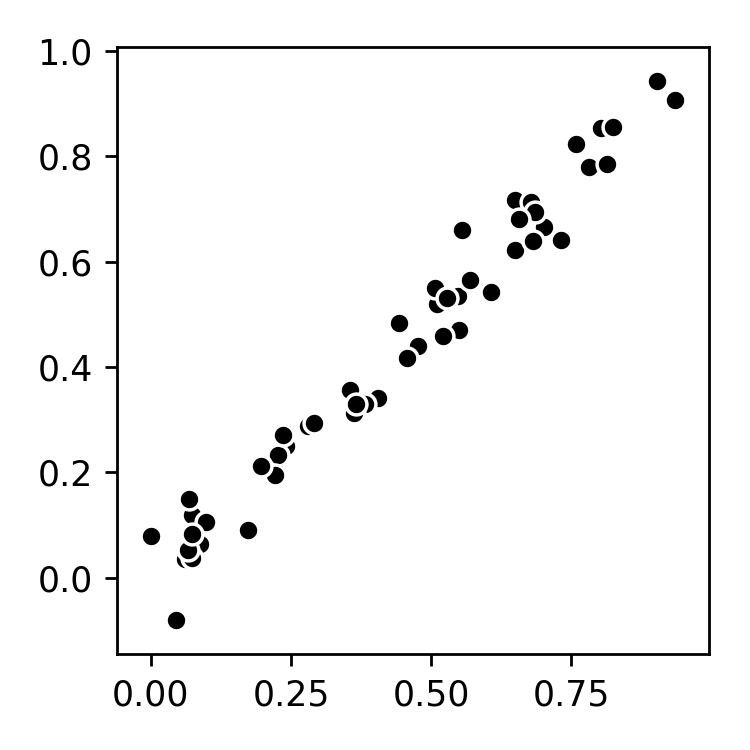

```python
# load in data
data = np.loadtxt('../../mlrefined_datasets/superlearn_datasets/2d_linregress_data.csv',delimiter=',')
x = data[:,:-1]
y = data[:,-1:]

# pack ones into x to simplify code
o = np.ones((len(y),1))
x = np.concatenate((o,x),axis = 1)

# scatter plot the input data
fig, ax = plt.subplots(1, 1, figsize=(3,3))
ax.scatter(data[:,0],data[:,1],color = 'k',edgecolor = 'w')
```

Now lets run coordinate descent.

```python
# run your alternating descent code
max_its = 15
w_history = coordinate_descent_for_LS(x,y,max_its)
```

With the run complete we plot the cost function decrease at each weight update.

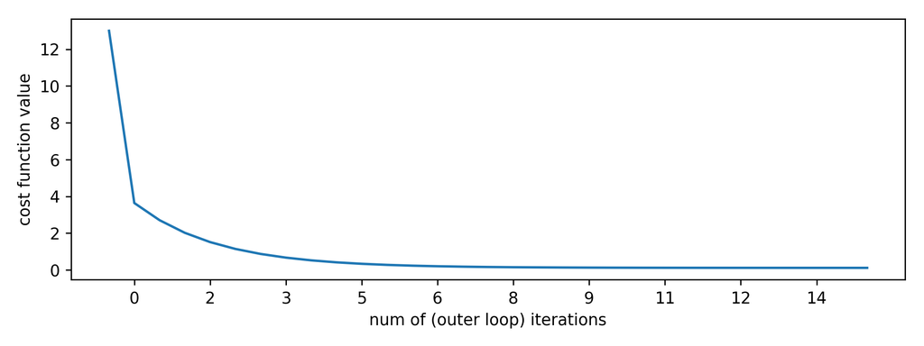

```python
# draw the cost function decrease plot
g = lambda w: np.sum((np.dot(x,w) - y)**2)

# plot resulting cost function history based on w_history
demo = optlib.coord_descent_plotter.Visualizer();
demo.plot_coord_descent_cost_history(g,w_history)
```

Since there are only two weights we can visualize the descent path on the cost contour - which we do in the next Python cell.

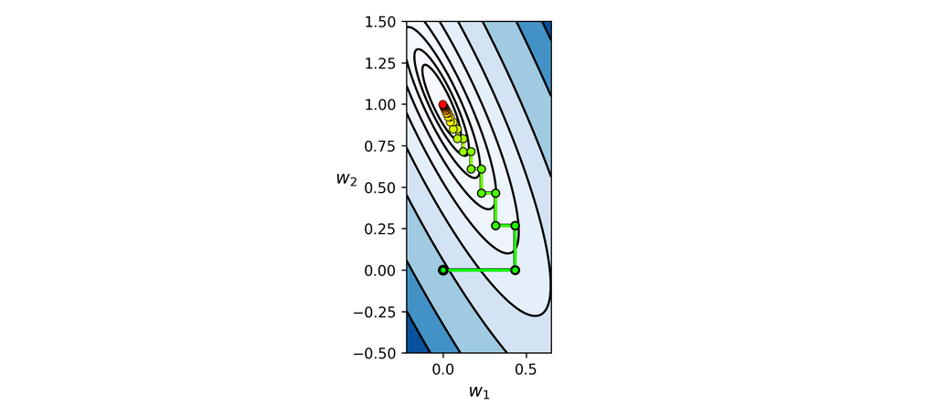

```
354.973638028
```

```python
# plot the path taken by alternating descent by plotting each weight from your history
g = lambda w: np.sum((np.dot(x,w) - y)**2)

# plot the contours
demo.show_path(g,w_history,num_contours = 25)
```

Now let us visualize the fit provided by the final weights

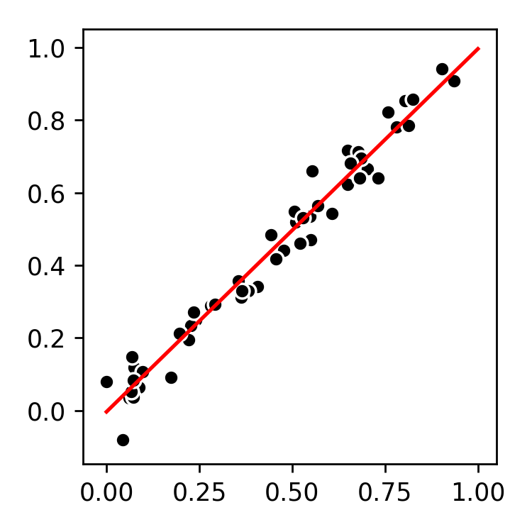

```python
# our initial weights
w = w_history[-1]

# scatter plot the input data
fig, ax = plt.subplots(1, 1, figsize=(3,3))
ax.scatter(data[:,0],data[:,1],color = 'k',edgecolor = 'w')

# fit a trend line
x_vals = np.linspace(0,1,200)
y_vals = [w[0] + w[1]*v for v in x_vals]
ax.plot(x_vals,y_vals,color = 'red')
plt.show()
```

The next Python cell loads in a dataset of 100 input/output pairs from a 10 dimensional dataset. This dataset was constructed by randomly sampling a 10-dimensional hyperplane, so using linear regression we should be able to find a good linear fit to it.

```python
# load in dataset
data = np.loadtxt('../../mlrefined_datasets/superlearn_datasets/highdim_linregress_data.csv',delimiter=',')

# form the input/output data vectors
x = data[:,:-1]
y = data[:,-1:]

# pack ones into x to simplify code
o = np.ones((len(y),1))
x = np.concatenate((o,x),axis = 1)
```

Running coordinate descent for 50 iterations leads to a point very close to the minimum.

```python
# run your alternating descent code
max_its = 50
w_history = coordinate_descent_for_LS(x,y,max_its)
```

We can now plot the cost function value over each weight update.

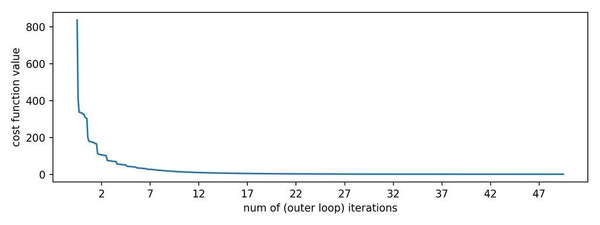

```python
# Our compact least squares function
g = lambda w: np.sum((np.dot(x,w) - y)**2)

# plot resulting cost function history based on w_history
demo = optlib.coord_descent_plotter.Visualizer();
demo.plot_coord_descent_cost_history(g,w_history)
```

#### Example 2: Logistic regression

For a dataset of $P$ points $\left(\mathbf{x}_{1},y_{1}\right),\,\left(\mathbf{x}_{2},y_{2}\right),\,...,\,\left(\mathbf{x}_{P},y_{P}\right)$ we re-annotate using the compact notation

\begin{equation} \mathbf{w} \longleftarrow \left[\begin{array}{c} w_{0}\\ \mathbf{w} \end{array}\right] \,\,\,\,\text{and}\,\,\,\,\, \mathbf{x}_{p}\longleftarrow\left[\begin{array}{c} 1\\ \mathbf{x}_{p}. \end{array}\right] \end{equation}

\begin{equation} \,g\left(\mathbf{w}\right)=\sum_{p=1}^{P}\text{log}\left(1 + e^{-y_{p}\mathbf{x}_{p}^{T}\mathbf{w} } \right). \end{equation}

Computing the partial derivative of the above in the $n^{th}$ weight alone we have

\begin{equation} \frac{\partial}{\partial w_n} g = -\sum_{p=1}^{P} \frac{ e^{-y_{p}\mathbf{x}_{p}^{T}\mathbf{w}} }{1 + e^{-y_{p}\mathbf{x}_{p}^{T}\mathbf{w}} }x_{p,n}y_p \end{equation}

Equivalently multiplying each summand by $1 = \frac{e^{-y_{p}\mathbf{x}_{p}^{T}\mathbf{w}} }{ e^{-y_{p}\mathbf{x}_{p}^{T}\mathbf{w}} }$ the above can be written equivalently as

\begin{equation} \frac{\partial}{\partial w_n} g = -\sum_{p=1}^{P} \frac{ 1 }{1 + e^{y_{p}\mathbf{x}_{p}^{T}\mathbf{w}} }x_{p,n}y_p \end{equation}

The second partial in $w_n$ can then be computed as

\begin{equation} \frac{\partial}{\partial w_n} g = \sum_{p=1}^{P} \frac{ e^{y_{p}\mathbf{x}_{p}^{T}\mathbf{w}^{\,}} }{\left( 1 + e^{y_{p}\mathbf{x}_{p}^{T}\mathbf{w}}\right)^2 }x_{p,n}^2 \end{equation}

Using the standard derivative rules we can then compute both the first and second partial derivatives in $w_n$, and write the Newton step in $w_n$ as

\begin{equation} w_n^{\,} = w_n^{\text{old}} - \frac{ -\sum_{p=1}^{P} \frac{ 1 }{1 + e^{y_{p}\mathbf{x}_{p}^{T}\mathbf{w}^{\text{old}}} }x_{p,n}y_p }{ \sum_{p=1}^{P} \frac{ e^{y_{p}\mathbf{x}_{p}^{T}\mathbf{w}^{\text{old}}} }{\left( 1 + e^{y_{p}\mathbf{x}_{p}^{T}\mathbf{w}^{\text{old}}}\right)^2 }x_{p,n}^2 }. \end{equation}

We provide an implementation of coordinate descent for logistic regression in the next Python cell. In this implementation we take just a single Newton step in each input direction when updating.

```python
def coordinate_descent_for_logistic(x,y,max_its):
    '''
    Coordinate descent for Least Squares
    X - the Px(N+1) data matrix
    y - the Px1 output vector
    '''

    # cost function for tol checking
    g = lambda w: np.sum(np.log(1 + np.exp(-y*np.dot(x,w))))

    # settings
    its = max_its                      # max its to run
    tol = 10**(-8)                     # tolerance to between sweeps to stop (optional)
    N = np.shape(x)[1]                 # length of weights
    w = np.zeros((N,1))                # initialization
    w_history = [copy.deepcopy(w)]     # record each weight for plotting

    # outer loop - each is a sweep through every variable once
    i = 0
    g_change = np.inf; gval1 = g(w);
    while i < its and g_change > tol:
        ### inner loop - each is a single variable update
        # update weights
        for n in range(N):
            # compute numerator of newton update
            temp1 = x[:,n:n+1]*y
            temp2 = y*np.dot(x,w)
            temp2 = [np.exp(v) for v in temp2]
            numer = -np.sum(np.asarray([v/(1 + r) for v,r in zip(temp1,temp2)]))

            # compute denominator
            temp3 = [v/(1 + v)**2 for v in temp2]
            temp4 = x[:,n:n+1]**2
            denom = np.sum(np.asarray([v*r for v,r in zip(temp3,temp4)]))

            # take newton step
            w[n] -= numer/denom

            # record weights at each step for kicks
            w_history.append(copy.deepcopy(w))

        # update counter and tol measure
        gval2 = copy.deepcopy(gval1)
        gval1 = g(w)
        g_change = abs(gval1 - gval2)/float(np.size(w))
        i+=1
    return w_history
```

We can test out our algorithm on an $N= 2$ dimensional input example, so that we may also examine the descent path plotted on the contour map of the cost function.

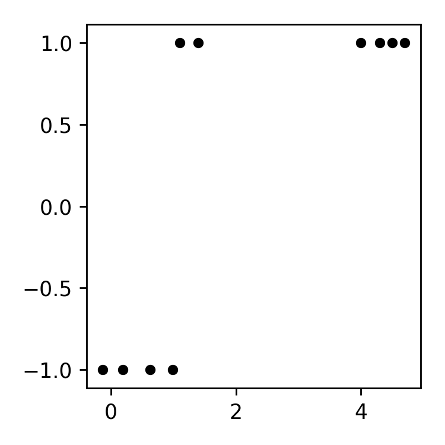

```python
# load in dataset
data = np.loadtxt('../../mlrefined_datasets/superlearn_datasets/2d_classification_data_v1.csv')
x = data[:,:-1:]
y = data[:,-1:]

# pack ones into x to simplify code
o = np.ones((len(y),1))
x = np.concatenate((o,x),axis = 1)

# scatter plot the input data
fig, ax = plt.subplots(1, 1, figsize=(3,3))
ax.scatter(data[:,0],data[:,1],color = 'k',edgecolor = 'w')
```

In the next Python cells we run coordinate descent, plot the cost function decrease plot over the run, plot the resulting descent run on the contour plot of the softmax function, and plot the fit resulting from the final weight of the run on the data itself..

```python
# run your alternating descent code
max_its = 50
w_history = coordinate_descent_for_logistic(x,y,max_its)
```

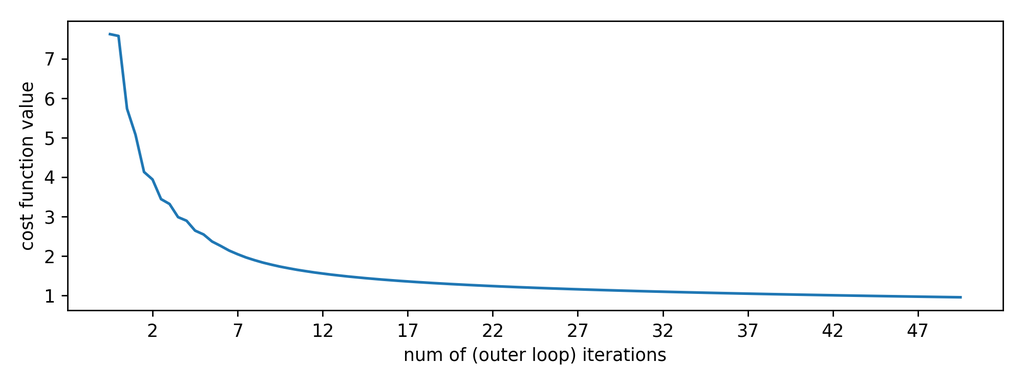

```python
# Our compact least squares function
g = lambda w: np.sum(np.log(1 + np.exp(-y*np.dot(x,w))))

# plot resulting cost function history based on w_history
demo = optlib.coord_descent_plotter.Visualizer();
demo.plot_coord_descent_cost_history(g,w_history)
```

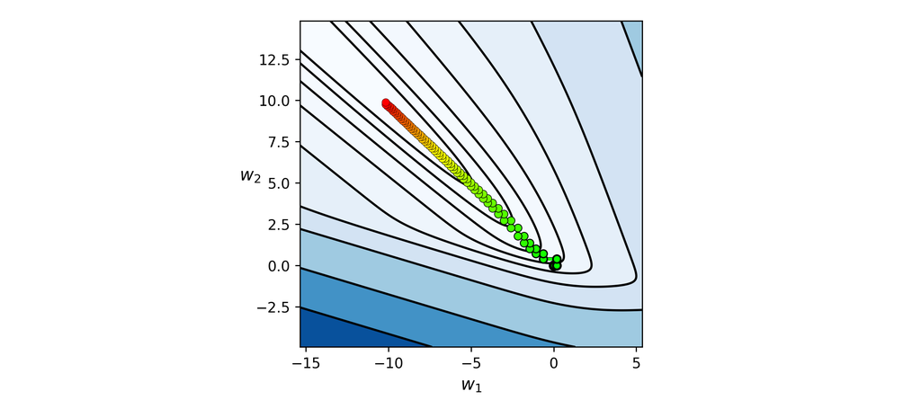

```python
# plot the path taken by alternating descent by plotting each weight from your history
g = lambda w: np.sum(np.log(1 + np.exp(-y*np.dot(x,w))))

# plot the contours
demo.show_path(g,w_history,num_contours = 25)
```

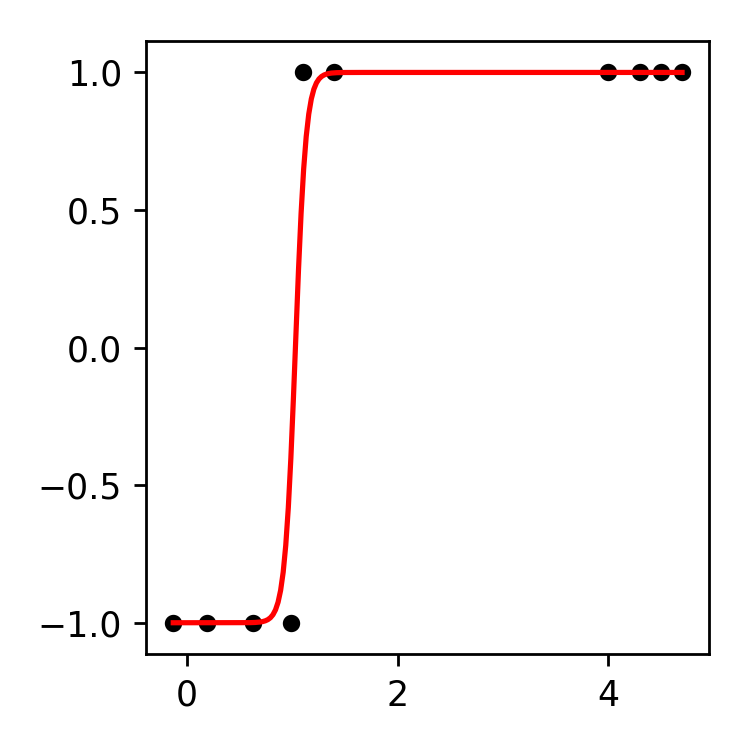

```python
# our initial weights
w = w_history[-1]

# scatter plot the input data
fig, ax = plt.subplots(1, 1, figsize=(3,3))
ax.scatter(data[:,0],data[:,1],color = 'k',edgecolor = 'w')

# fit a trend line
x_vals = np.linspace(min(data[:,0]),max(data[:,0]),200)
y_vals = [np.tanh(w[0] + w[1]*v) for v in x_vals]
ax.plot(x_vals,y_vals,color = 'red')
plt.show()
```

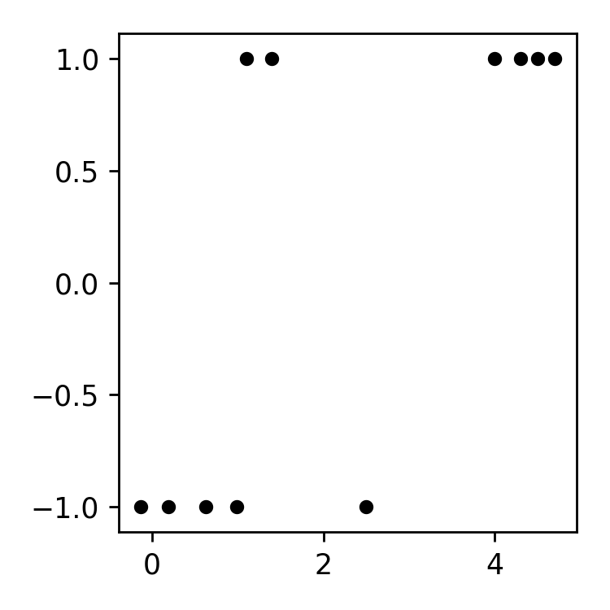

```python
# load in dataset
data = np.loadtxt('../../mlrefined_datasets/superlearn_datasets/2d_classification_data_v2.csv')
x = data[:,:-1:]
y = data[:,-1:]

# pack ones into x to simplify code
o = np.ones((len(y),1))
x = np.concatenate((o,x),axis = 1)

# scatter plot the input data
fig, ax = plt.subplots(1, 1, figsize=(3,3))
ax.scatter(data[:,0],data[:,1],color = 'k',edgecolor = 'w')
```

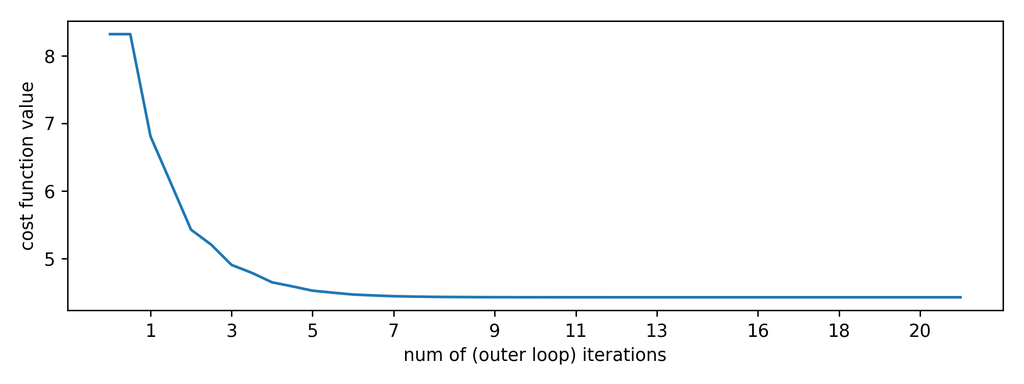

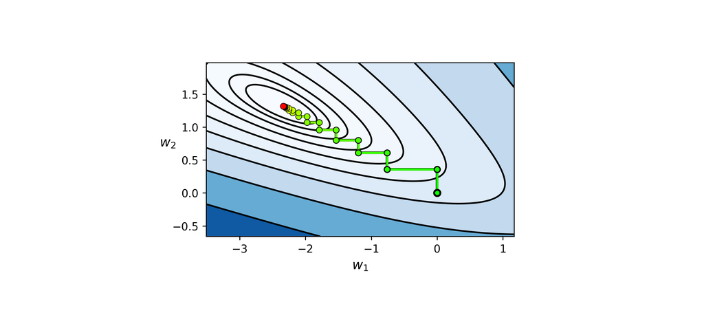

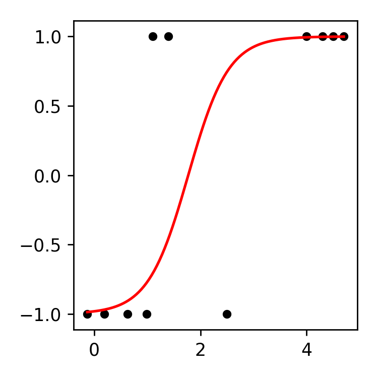

```python
# run your alternating descent code
max_its = 30
w_history = coordinate_descent_for_logistic(x,y,max_its)

# Our compact least squares function
g = lambda w: np.sum(np.log(1 + np.exp(-y*np.dot(x,w))))

# plot resulting cost function history based on w_history
demo = optlib.coord_descent_plotter.Visualizer();
demo.plot_coord_descent_cost_history(g,w_history)

# plot the path taken by alternating descent by plotting each weight from your history
g = lambda w: np.sum(np.log(1 + np.exp(-y*np.dot(x,w))))

# plot the contours
demo.show_path(g,w_history,num_contours = 25)

# our initial weights
w = w_history[-1]

# scatter plot the input data
fig, ax = plt.subplots(1, 1, figsize=(3,3))
ax.scatter(data[:,0],data[:,1],color = 'k',edgecolor = 'w')

# fit a trend line
x_vals = np.linspace(min(data[:,0]),max(data[:,0]),200)
y_vals = [np.tanh(w[0] + w[1]*v) for v in x_vals]
ax.plot(x_vals,y_vals,color = 'red')
plt.show()
```

© This material is not to be distributed, copied, or reused without written permission from the authors.